# Clustering en R - 1

Salvador Carrillo Fuentes

Mayo/2019

## Opciones para visualizar tablas desde *RMarkdown*

> Opción 1

```r
library(knitr)
library(kableExtra)
options(knitr.table.format = "html")
```

> Opción 2

```r
library(DT)
```

## *Clustering k-means*

> Algoritmo *k-means*:
- Recibe $2$ parámetros: $k$ (número de *clusters*) y $x_1, ..., x_n$ (conjunto de puntos)
1. Seleccionamos $k$ *centroides* de manera aleatoria
2. Repetimos lo siguiente hasta converger:
- Para cada punto $x_i$:
  - Encontrar el *centroide* $c_j$ más cercano al punto $x_i$
  - Asignamos el punto $x_i$ al *cluster* $j$
- Para cada *cluster* $j$:
  - Recalculamos los nuevos *centroides* como la media de los puntos $x_i$ del *cluster* $j$

> Algoritmo *k-means* en *R* (parámetros más interesantes):

```r
kmeans(x, centers, iter.max = 10, nstart = 1)

#Ejemplo:
grpMeat <- kmeans(dataset[,c("Atributo1","Atributo2","Atributo3")], centers=5, nstart=10)
```

- $x$: matriz numérica de datos (o un objeto que pueda ser transformado a una matriz, como un vector numérico o un *data frame* con columnas numéricas)
- $centers$: número de *clusters* o un conjunto de *centroides* distintos. Si se proporciona un número, se generan los *centroides* de forma aleatoria.
- $iter.max$: máximas iteraciones permitidas
- $nstart$: si $centers$ es un número, se generan $10$ *centroides* y se seleccionan los mejores.

## Explorando el dataset

> Usaremos el dataset *protein.csv* del CV conteniendo datos de 25 países europeos que almacenan la ingesta de proteínas de 9 fuentes de proteínas (atributos) en tantos por ciento.

```r
library(readr)
food <- read_csv("protein.csv")
food <- as.data.frame(food) # IMPORTANTE!

head(food) %>% kable("html")
```

| Country | RedMeat | WhiteMeat | Eggs | Milk | Fish | Cereals | Starch | Nuts | Fr&Veg |
| --- | --- | --- | --- | --- | --- | --- | --- | --- | --- |
| Albania | 10.1 | 1.4 | 0.5 | 8.9 | 0.2 | 42.3 | 0.6 | 5.5 | 1.7 |
| Austria | 8.9 | 14.0 | 4.3 | 19.9 | 2.1 | 28.0 | 3.6 | 1.3 | 4.3 |
| Belgium | 13.5 | 9.3 | 4.1 | 17.5 | 4.5 | 26.6 | 5.7 | 2.1 | 4.0 |
| Bulgaria | 7.8 | 6.0 | 1.6 | 8.3 | 1.2 | 56.7 | 1.1 | 3.7 | 4.2 |
| Czechoslovakia | 9.7 | 11.4 | 2.8 | 12.5 | 2.0 | 34.3 | 5.0 | 1.1 | 4.0 |
| Denmark | 10.6 | 10.8 | 3.7 | 25.0 | 9.9 | 21.9 | 4.8 | 0.7 | 2.4 |

```r
# 25 países y 9 tipos de comida
dim(food)
```

```
## [1] 25 10
```

> Extraigo las comidas

```r
my.foods <-food[,2:dim(food)[2]]
my.foods %>%
  kable("html") %>%
  kable_styling(bootstrap_options = c("striped", full_width = F))
```

| RedMeat | WhiteMeat | Eggs | Milk | Fish | Cereals | Starch | Nuts | Fr&Veg |
| --- | --- | --- | --- | --- | --- | --- | --- | --- |
| 10.1 | 1.4 | 0.5 | 8.9 | 0.2 | 42.3 | 0.6 | 5.5 | 1.7 |
| 8.9 | 14.0 | 4.3 | 19.9 | 2.1 | 28.0 | 3.6 | 1.3 | 4.3 |
| 13.5 | 9.3 | 4.1 | 17.5 | 4.5 | 26.6 | 5.7 | 2.1 | 4.0 |
| 7.8 | 6.0 | 1.6 | 8.3 | 1.2 | 56.7 | 1.1 | 3.7 | 4.2 |
| 9.7 | 11.4 | 2.8 | 12.5 | 2.0 | 34.3 | 5.0 | 1.1 | 4.0 |
| 10.6 | 10.8 | 3.7 | 25.0 | 9.9 | 21.9 | 4.8 | 0.7 | 2.4 |
| 8.4 | 11.6 | 3.7 | 11.1 | 5.4 | 24.6 | 6.5 | 0.8 | 3.6 |
| 9.5 | 4.9 | 2.7 | 33.7 | 5.8 | 26.3 | 5.1 | 1.0 | 1.4 |
| 18.0 | 9.9 | 3.3 | 19.5 | 5.7 | 28.1 | 4.8 | 2.4 | 6.5 |
| 10.2 | 3.0 | 2.8 | 17.6 | 5.9 | 41.7 | 2.2 | 7.8 | 6.5 |
| 5.3 | 12.4 | 2.9 | 9.7 | 0.3 | 40.1 | 4.0 | 5.4 | 4.2 |
| 13.9 | 10.0 | 4.7 | 25.8 | 2.2 | 24.0 | 6.2 | 1.6 | 2.9 |
| 9.0 | 5.1 | 2.9 | 13.7 | 3.4 | 36.8 | 2.1 | 4.3 | 6.7 |
| 9.5 | 13.6 | 3.6 | 23.4 | 2.5 | 22.4 | 4.2 | 1.8 | 3.7 |
| 9.4 | 4.7 | 2.7 | 23.3 | 9.7 | 23.0 | 4.6 | 1.6 | 2.7 |
| 6.9 | 10.2 | 2.7 | 19.3 | 3.0 | 36.1 | 5.9 | 2.0 | 6.6 |
| 6.2 | 3.7 | 1.1 | 4.9 | 14.2 | 27.0 | 5.9 | 4.7 | 7.9 |
| 6.2 | 6.3 | 1.5 | 11.1 | 1.0 | 49.6 | 3.1 | 5.3 | 2.8 |
| 7.1 | 3.4 | 3.1 | 8.6 | 7.0 | 29.2 | 5.7 | 5.9 | 7.2 |
| 9.9 | 7.8 | 3.5 | 24.7 | 7.5 | 19.5 | 3.7 | 1.4 | 2.0 |
| 13.1 | 10.1 | 3.1 | 23.8 | 2.3 | 25.6 | 2.8 | 2.4 | 4.9 |
| 17.4 | 5.7 | 4.7 | 20.6 | 4.3 | 24.3 | 4.7 | 3.4 | 3.3 |
| 9.3 | 4.6 | 2.1 | 16.6 | 3.0 | 43.6 | 6.4 | 3.4 | 2.9 |
| 11.4 | 12.5 | 4.1 | 18.8 | 3.4 | 18.6 | 5.2 | 1.5 | 3.8 |
| 4.4 | 5.0 | 1.2 | 9.5 | 0.6 | 55.9 | 3.0 | 5.7 | 3.2 |

```r
# my.foods %>% datatable()
```

> Analizamos información contenida en el dataset:

```r
# Medias de consumo de cada tipo de alimento
my.foods %>%
  colMeans() %>%
  round(1) %>%
  sort() %>%
  kable("html")
```

|  | x |
| --- | --- |
| Eggs | 2.9 |
| Nuts | 3.1 |
| Fr&Veg | 4.1 |
| Fish | 4.3 |
| Starch | 4.3 |
| WhiteMeat | 7.9 |
| RedMeat | 9.8 |
| Milk | 17.1 |
| Cereals | 32.2 |

```r
# Desviación estándar
my.foods %>%
  apply(2, sd) %>%
  round(1) %>%
  sort() %>%
  kable("html")
```

|  | x |
| --- | --- |
| Eggs | 1.1 |
| Starch | 1.6 |
| Fr&Veg | 1.8 |
| Nuts | 2.0 |
| RedMeat | 3.3 |
| Fish | 3.4 |
| WhiteMeat | 3.7 |
| Milk | 7.1 |
| Cereals | 11.0 |

> Intentaremos hacer *clustering* según la ingesta de carne blanca (*WhiteMeat*) y carne roja (*RedMeat*). El número de *clusters* será $3$. Los *clusters* se forman minimizando la distancia euclídea a los respectivos *centroides* de cada grupo.

```r
set.seed(1)   ## para fijar los clusters aleatorios de inicio
grpMeat <- kmeans(food[,c("WhiteMeat","RedMeat")], centers=3, nstart=10)
str(grpMeat)
```

```
## List of 9
##  $ cluster     : int [1:25] 1 3 2 1 3 3 3 1 2 1 ...
##  $ centers     : num [1:3, 1:2] 4.66 9 12.06 8.26 15.18 ...
##   ..- attr(*, "dimnames")=List of 2
##   .. ..$ : chr [1:3] "1" "2" "3"
##   .. ..$ : chr [1:2] "WhiteMeat" "RedMeat"
##  $ totss       : num 596
##  $ withinss    : num [1:3] 69.9 35.7 39.5
##  $ tot.withinss: num 145
##  $ betweenss   : num 451
##  $ size        : int [1:3] 12 5 8
##  $ iter        : int 2
##  $ ifault      : int 0
##  - attr(*, "class")= chr "kmeans"
```

```r
grpMeat
```

```
## K-means clustering with 3 clusters of sizes 12, 5, 8
##
## Cluster means:
##   WhiteMeat   RedMeat
## 1  4.658333  8.258333
## 2  9.000000 15.180000
## 3 12.062500  8.837500
##
## Clustering vector:
##  [1] 1 3 2 1 3 3 3 1 2 1 3 2 1 3 1 3 1 1 1 1 2 2 1 3 1
##
## Within cluster sum of squares by cluster:
## [1] 69.85833 35.66800 39.45750
##  (between_SS / total_SS =  75.7 %)
##
## Available components:
##
## [1] "cluster"      "centers"      "totss"        "withinss"
## [5] "tot.withinss" "betweenss"    "size"         "iter"
## [9] "ifault"
```

> Los grupos han sido calculados. Pasamos a explorar la información obtenida.

```r
## Lista ordenada de los grupos
Gr1 = order(grpMeat$cluster)
# Los índices que se usarán a continuación para ver los clusters
Gr1
```

```
##  [1]  1  4  8 10 13 15 17 18 19 20 23 25  3  9 12 21 22  2  5  6  7 11 14
## [24] 16 24
```

```r
# Visualizamos cada país con su cluster de forma ordenada
data.frame(food$Country[Gr1],grpMeat$cluster[Gr1])
```

```
##    food.Country.Gr1. grpMeat.cluster.Gr1.
## 1            Albania                    1
## 2           Bulgaria                    1
## 3            Finland                    1
## 4             Greece                    1
## 5              Italy                    1
## 6             Norway                    1
## 7           Portugal                    1
## 8            Romania                    1
## 9              Spain                    1
## 10            Sweden                    1
## 11              USSR                    1
## 12        Yugoslavia                    1
## 13           Belgium                    2
## 14            France                    2
## 15           Ireland                    2
## 16       Switzerland                    2
## 17                UK                    2
## 18           Austria                    3
## 19    Czechoslovakia                    3
## 20           Denmark                    3
## 21         E Germany                    3
## 22           Hungary                    3
## 23       Netherlands                    3
## 24            Poland                    3
## 25         W Germany                    3
```

[figure not shown]

```r
plot(food$RedMeat, food$WhiteMeat, type="n", xlim=c(3,19), xlab="Red Meat", ylab="White Meat")
```

> Visualizamos los grupos según tipo de carne (*Red*, *White*):

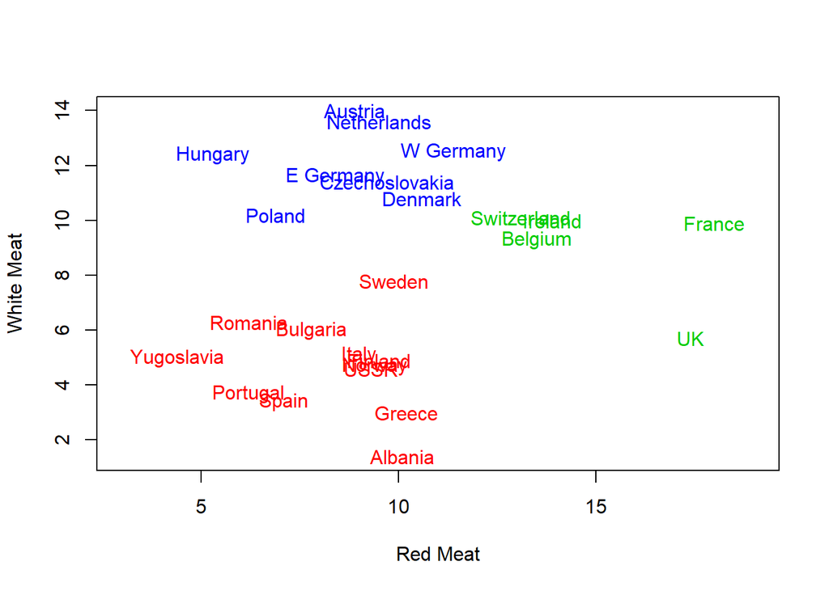

```r
plot(food$RedMeat, food$WhiteMeat, type="n", xlim=c(3,19), xlab="Red Meat", ylab="White Meat")

text(x=food$RedMeat, y=food$WhiteMeat, labels=food$Country, col=grpMeat$cluster+1)
```

> Aplicamos ahora *clustering* teniendo en cuenta los $9$ atributos buscando $7$ *clusters.*

```r
set.seed(1)
grpProtein <- kmeans(food[,-1], centers=7, nstart=10)
Gr1=order(grpProtein$cluster)
data.frame(food$Country[Gr1],grpProtein$cluster[Gr1])
```

```
##    food.Country.Gr1. grpProtein.cluster.Gr1.
## 1           Portugal                       1
## 2              Spain                       1
## 3            Denmark                       2
## 4            Finland                       2
## 5             Norway                       2
## 6             Sweden                       2
## 7            Austria                       3
## 8          E Germany                       3
## 9        Netherlands                       3
## 10         W Germany                       3
## 11    Czechoslovakia                       4
## 12           Hungary                       4
## 13            Poland                       4
## 14           Belgium                       5
## 15            France                       5
## 16           Ireland                       5
## 17       Switzerland                       5
## 18                UK                       5
## 19          Bulgaria                       6
## 20           Romania                       6
## 21        Yugoslavia                       6
## 22           Albania                       7
## 23            Greece                       7
## 24             Italy                       7
## 25              USSR                       7
```

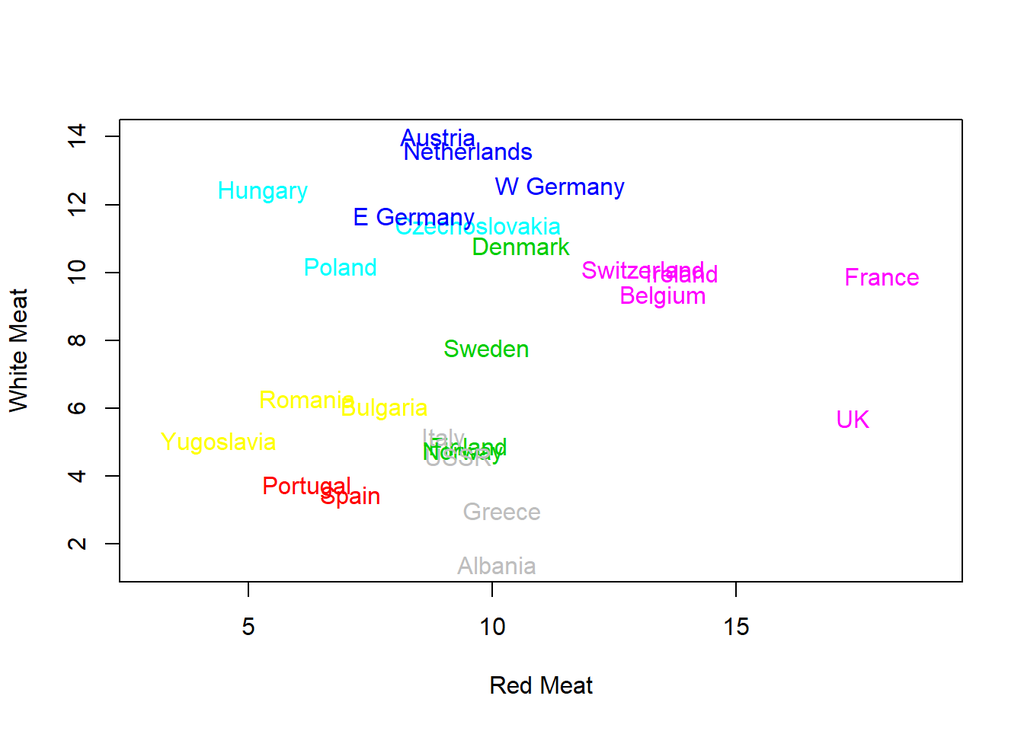

```r
## plotting cluster assignments on Red and White meat scatter plot
plot(food$RedMeat, food$WhiteMeat, type="n", xlim=c(3,19), xlab="Red Meat", ylab="White Meat")

text(x=food$RedMeat, y=food$WhiteMeat, labels=food$Country, col=grpProtein$cluster+1)
```

## Calculando distancias

```r
# ? dist
# This function computes and returns the distance matrix computed by using the specified distance measure to compute the distances between the rows of a data matrix.

distances.countries = dist(my.foods)
class(distances.countries)
```

```
## [1] "dist"
```

```r
distances.countries %>%
  as.matrix() %>%
  datatable()
```

|  | 1 | 2 | 3 | 4 | 5 | 6 | 7 | 8 | 9 | 10 | 11 | 12 | 13 | 14 | 15 | 16 | 17 | 18 | 19 | 20 | 21 | 22 | 23 | 24 | 25 |
| --- | --- | --- | --- | --- | --- | --- | --- | --- | --- | --- | --- | --- | --- | --- | --- | --- | --- | --- | --- | --- | --- | --- | --- | --- | --- |
| 1 | 0 | 23.1762809786212 | 21.6501732094688 | 15.6882121352307 | 15.1545372743611 | 30.1575861102974 | 22.8659134958567 | 30.9909664257183 | 23.1741235001456 | 12.1363091588835 | 13.1571273460433 | 27.9025088477721 | 10.6244999882347 | 28.3021200619318 | 26.8054099017344 | 17.6439791430391 | 23.1110363246653 | 10.3193992073182 | 17.1499271135477 | 29.9879975990395 | 24.9288988926507 | 24.3084347501027 | 11.034038245357 | 29.1439530606265 | 15.4748182541831 |
| 2 | 23.1762809786212 | 0 | 7.86829079279611 | 32.3044888521704 | 10.3053384223906 | 11.9565881421081 | 10.7429046351534 | 17.4212513901843 | 11.0109036868006 | 19.5297209401466 | 16.9749815905644 | 10.0394222941363 | 14.6887712215828 | 6.76387462923434 | 13.6846629479867 | 9.94233373006559 | 22.9312014512977 | 25.2612351241977 | 17.4401834852733 | 13.0322676461159 | 7.58353479585872 | 12.9205263050698 | 19.0428464258892 | 10.1316336293808 | 31.9469873384017 |
| 3 | 21.6501732094688 | 7.86829079279611 | 0 | 32.7861251141394 | 10.6099010362962 | 11.1198021565134 | 8.92860571421989 | 17.6031247226167 | 6.00749531835024 | 18.2548623659561 | 18.7840357750937 | 9.1465840618233 | 13.5687140142314 | 9.67574286553751 | 10.8037030688556 | 12.2016392341357 | 19.2007812341061 | 25.87856255668 | 13.9165369255429 | 11.6322826650662 | 7.52595508889071 | 6.83008052661167 | 18.4168401198468 | 9.06642156531451 | 32.6848588799156 |
| 4 | 15.6882121352307 | 32.3044888521704 | 32.7861251141394 | 0 | 24.0054160555488 | 40.3341046758199 | 33.6147289145696 | 40.3350963801997 | 33.2634935026374 | 19.3155377869735 | 18.3991847645487 | 38.3597445246967 | 21.0133291032145 | 38.5267439579314 | 38.1747298615197 | 24.4938767858418 | 33.2938432746957 | 8.33486652562595 | 28.8873674813057 | 41.4805978741869 | 35.509012940379 | 36.419500271146 | 16.675431028912 | 40.6198227470283 | 4.87544869729956 |
| 5 | 15.1545372743611 | 10.3053384223906 | 10.6099010362962 | 24.0054160555488 | 0 | 19.4206076115038 | 10.6136704301575 | 24.0199916736039 | 13.4350288425444 | 15.025644744902 | 9.17986928011505 | 17.5820931632158 | 8.70517087712815 | 16.3526756220504 | 18.7272528684802 | 8.25530132702617 | 19.0604302155014 | 17.3115568335144 | 13.0705776459956 | 20.4303695512343 | 14.9716398567425 | 16.497272501841 | 12.6352681016273 | 17.1513847837427 | 23.9776979712399 |
| 6 | 30.1575861102974 | 11.9565881421081 | 11.1198021565134 | 40.3341046758199 | 19.4206076115038 | 0 | 15.1845316029175 | 12.2498979587587 | 12.7184904764677 | 24.4660989943227 | 26.7348087705897 | 8.93812060782355 | 21.5958329313782 | 8.36002392341075 | 6.68804904288239 | 17.8137587274556 | 23.9269722280108 | 33.2921912766342 | 21.1877322996115 | 4.79583152331272 | 9.6503885932122 | 11.7405280971513 | 25.3347587318293 | 9.90101004948485 | 39.8741771074965 |
| 7 | 22.8659134958567 | 10.7429046351534 | 8.92860571421989 | 33.6147289145696 | 10.6136704301575 | 15.1845316029175 | 0 | 23.8275051148877 | 13.8553238865066 | 22.1092740722078 | 17.5179907523666 | 16.1777625152553 | 15.6227398365332 | 13.2687603038114 | 14.9853261559434 | 14.8748109231681 | 15.1561868555386 | 26.7316292058677 | 11.7843116048414 | 15.5842869583437 | 14.6471840297035 | 14.7800541270998 | 21.3691366227089 | 10.5584089710524 | 33.2794230719224 |
| 8 | 30.9909664257183 | 17.4212513901843 | 17.6031247226167 | 40.3350963801997 | 24.0199916736039 | 12.2498979587587 | 23.8275051148877 | 0 | 18.1813090837816 | 24.1070529098851 | 29.9838289749658 | 11.5693560754262 | 23.755420434082 | 14.6775338527969 | 11.6880280629369 | 19.3589772457121 | 31.1762730293408 | 33.3980538355156 | 26.571413210441 | 11.9088202606304 | 13.0541181241783 | 15.9511755052723 | 24.6927114752512 | 18.8788241159242 | 39.3300139842335 |
| 9 | 23.1741235001456 | 11.0109036868006 | 6.00749531835024 | 33.2634935026374 | 13.4350288425444 | 12.7184904764677 | 13.8553238865066 | 18.1813090837816 | 0 | 18.2545884642739 | 21.2562931857838 | 10.1533245786787 | 15.1578362571971 | 12.350303639992 | 13.1502851680106 | 14.0132080552599 | 21.8540614074364 | 27.1169688571566 | 17.2151096424043 | 14.0271165960792 | 8.18229796573065 | 6.98713102782537 | 19.4342481202644 | 12.4599357943771 | 33.7231374578345 |
| 10 | 12.1363091588835 | 19.5297209401466 | 18.2548623659561 | 19.3155377869735 | 15.025644744902 | 24.4660989943227 | 22.1092740722078 | 24.1070529098851 | 18.2545884642739 | 0 | 14.9331845230681 | 22.9765097436491 | 7.976841480185 | 24.0628344132606 | 21.4196171767845 | 12.3588025309898 | 22.1564888915189 | 13.3416640641263 | 16.2686815691991 | 25.1573051020971 | 20.0399600798006 | 20.3201870070135 | 8.17557337438788 | 26.2804109556909 | 18.7477998709182 |

[output cut: 15 more lines]

```r
# Miramos lista de países:

data.frame(id=seq(1:dim(food)[1]),country=food[,'Country']) %>% kable("html")
```

| id | country |
| --- | --- |
| 1 | Albania |
| 2 | Austria |
| 3 | Belgium |
| 4 | Bulgaria |
| 5 | Czechoslovakia |
| 6 | Denmark |
| 7 | E Germany |
| 8 | Finland |
| 9 | France |
| 10 | Greece |
| 11 | Hungary |
| 12 | Ireland |
| 13 | Italy |
| 14 | Netherlands |
| 15 | Norway |
| 16 | Poland |
| 17 | Portugal |
| 18 | Romania |
| 19 | Spain |
| 20 | Sweden |
| 21 | Switzerland |
| 22 | UK |
| 23 | USSR |
| 24 | W Germany |
| 25 | Yugoslavia |

```r
# Distancias entre los dos países
as.matrix(distances.countries)[5,19]
```

```
## [1] 13.07058
```

```r
#  Calculándolo manualmente
sqrt(sum((my.foods[5,]-my.foods[19,])**2))
```

```
## [1] 13.07058
```

## *Hierarchical Clustering*

En *clustering* se utiliza un tipo de diagrama llamado **dendrograma** para visualizar los grupos.

Generamos un *dendrograma* a partir de las distancias entre países calculadas anteriormente.

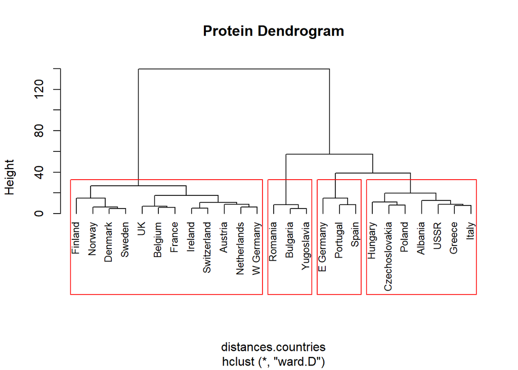

```r
clusters = hclust(distances.countries, method="ward.D")

plot(clusters, main="Protein Dendrogram", labels=food[,1], cex=0.8, hang=-1)
rect.hclust(clusters, k=4)
```

Se pueden ver $4$ *clusters* y las similaridades entre países que van disminuyendo si vamos subiendo desde las hojas del dendrograma.

- Dinamarca y Suecia en el mismo grupo
- Mayor similaridad de Dinamarca con Suecia que con Noruega aunque estén en el mismo grupo.

Analizamos cómo se van conectando los países según distancias:

```r
clusters$merge
```

```
##       [,1] [,2]
##  [1,]   -6  -20
##  [2,]   -4  -25
##  [3,]  -12  -21
##  [4,]   -3   -9
##  [5,]  -14  -24
##  [6,]  -15    1
##  [7,]  -22    4
##  [8,]  -10  -13
##  [9,]   -5  -16
## [10,]  -18    2
## [11,]  -17  -19
## [12,]   -2    5
## [13,]  -23    8
## [14,]    3   12
## [15,]  -11    9
## [16,]   -1   13
## [17,]   -7   11
## [18,]   -8    6
## [19,]    7   14
## [20,]   15   16
## [21,]   18   19
## [22,]   17   20
## [23,]   10   22
## [24,]   21   23
```

En la tabla anterior vemos números con símbolo $-$ delante y otros sin ese símbolo.

Vemos las conexiones en los niveles inferiores:

- g1: 6 Denmark con 20 Sweden
- g2: 4 Bulgaria con 25 Yugoslavia
- g3: 12 Ireland con 21 Switzerland
- g4: 3 Belgium con 9 France
- g5: 14 Netherlands con 24 W Germany

En este momento en la tabla aparece:

- -22 4

qué significa que $22$ *UK* está conectado con g4 ($3$ *Belgium* con $9$ *France*)

Y así sucesivamente

> Analizar países por *clusters*

Conectaremos cada país con su *cluster*:

```r
food$cluster = cutree(clusters, k=4)
head(food) %>% datatable()
```

|  | Country | RedMeat | WhiteMeat | Eggs | Milk | Fish | Cereals | Starch | Nuts | Fr&Veg | cluster |
| --- | --- | --- | --- | --- | --- | --- | --- | --- | --- | --- | --- |
| 1 | Albania | 10.1 | 1.4 | 0.5 | 8.9 | 0.2 | 42.3 | 0.6 | 5.5 | 1.7 | 1 |
| 2 | Austria | 8.9 | 14 | 4.3 | 19.9 | 2.1 | 28 | 3.6 | 1.3 | 4.3 | 2 |
| 3 | Belgium | 13.5 | 9.3 | 4.1 | 17.5 | 4.5 | 26.6 | 5.7 | 2.1 | 4 | 2 |
| 4 | Bulgaria | 7.8 | 6 | 1.6 | 8.3 | 1.2 | 56.7 | 1.1 | 3.7 | 4.2 | 3 |
| 5 | Czechoslovakia | 9.7 | 11.4 | 2.8 | 12.5 | 2 | 34.3 | 5 | 1.1 | 4 | 1 |
| 6 | Denmark | 10.6 | 10.8 | 3.7 | 25 | 9.9 | 21.9 | 4.8 | 0.7 | 2.4 | 2 |

```r
# tamaño de cada cluster
table(food$cluster)
```

```
##
##  1  2  3  4
##  7 12  3  3
```

```r
# Diferenciar clusters según las medias
names(food)[10] <- "Fr.Veg"
my.means = aggregate(cbind(RedMeat, WhiteMeat, Eggs, Milk, Fish,Cereals,Starch,Nuts,Fr.Veg)~cluster, food, mean)

my.means %>% datatable()
```

|  | cluster | RedMeat | WhiteMeat | Eggs | Milk | Fish | Cereals | Starch | Nuts | Fr.Veg |
| --- | --- | --- | --- | --- | --- | --- | --- | --- | --- | --- |
| 1 | 1 | 8.64285714285714 | 6.87142857142857 | 2.38571428571429 | 14.0428571428571 | 2.54285714285714 | 39.2714285714286 | 3.74285714285714 | 4.21428571428571 | 4.65714285714286 |
| 2 | 2 | 12.0916666666667 | 9.44166666666667 | 3.70833333333333 | 23 | 4.99166666666667 | 24.025 | 4.61666666666667 | 1.76666666666667 | 3.49166666666667 |
| 3 | 3 | 6.13333333333333 | 5.76666666666667 | 1.43333333333333 | 9.63333333333333 | 0.933333333333333 | 54.0666666666667 | 2.4 | 4.9 | 3.4 |
| 4 | 4 | 7.23333333333333 | 6.23333333333333 | 2.63333333333333 | 8.2 | 8.86666666666667 | 26.9333333333333 | 6.03333333333333 | 3.8 | 6.23333333333333 |

Visualizamos para cada *cluster* las medias de los cuatro primeros alimentos:

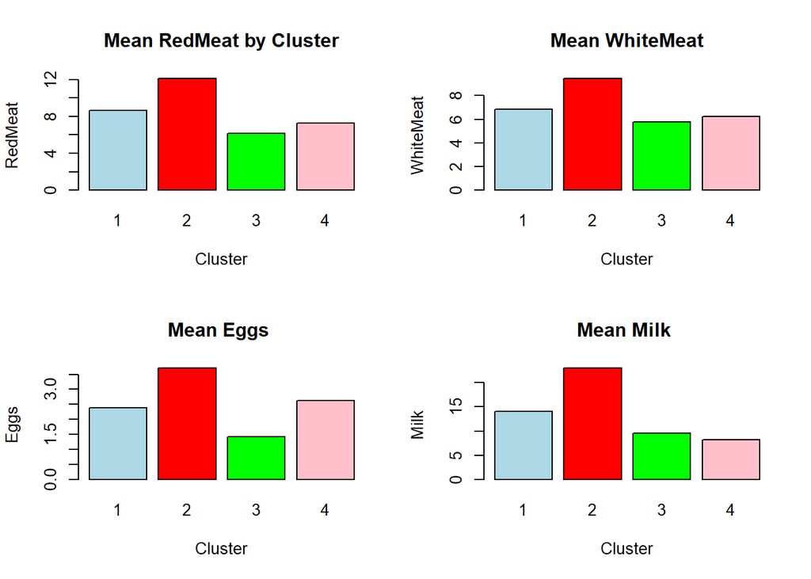

```r
par(mfrow=c(2,2))
eje_x = my.means[,1]
colors = c("lightblue" ,"red", "green", "pink")
barplot(my.means$RedMeat, main="Mean RedMeat by Cluster", names.arg=eje_x, xlab="Cluster", ylab="RedMeat", col=colors)
barplot(my.means$WhiteMeat, main="Mean WhiteMeat", names.arg=eje_x, xlab="Cluster", ylab="WhiteMeat", col=colors)
barplot(my.means$Eggs, main="Mean Eggs ", names.arg=eje_x, xlab="Cluster", ylab="Eggs", col=colors)
barplot(my.means$Milk, main="Mean Milk ", names.arg=eje_x, xlab="Cluster", ylab="Milk", col=colors)
```

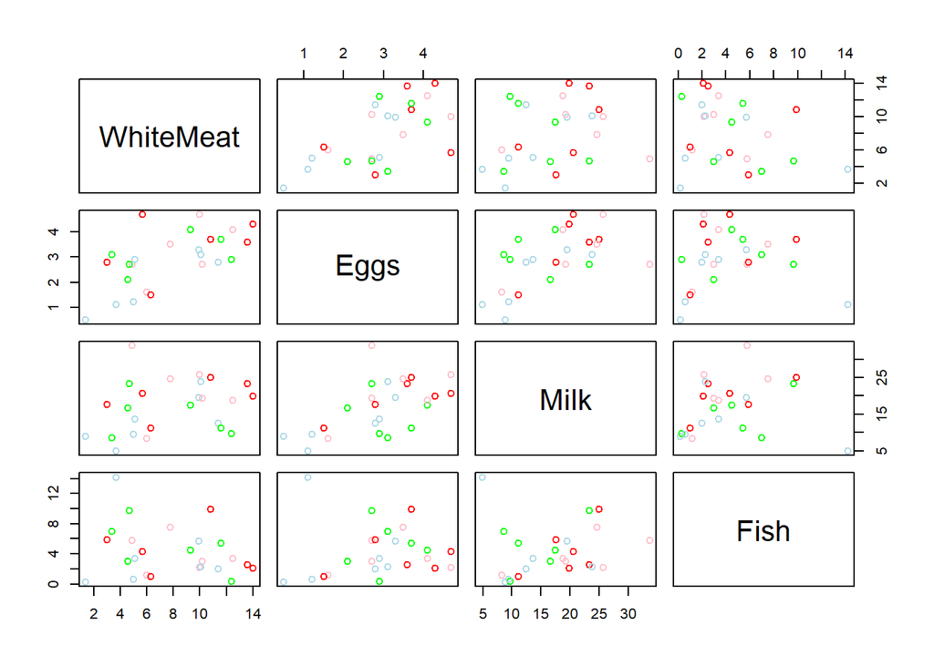

```r
plot(my.foods[,2:5], col=colors)
```

Alimentos principales en cada *cluster*:

```r
subset(food, food$cluster == 1) %>% kable("html")
```

|  | Country | RedMeat | WhiteMeat | Eggs | Milk | Fish | Cereals | Starch | Nuts | Fr.Veg | cluster |
| --- | --- | --- | --- | --- | --- | --- | --- | --- | --- | --- | --- |
| 1 | Albania | 10.1 | 1.4 | 0.5 | 8.9 | 0.2 | 42.3 | 0.6 | 5.5 | 1.7 | 1 |
| 5 | Czechoslovakia | 9.7 | 11.4 | 2.8 | 12.5 | 2.0 | 34.3 | 5.0 | 1.1 | 4.0 | 1 |
| 10 | Greece | 10.2 | 3.0 | 2.8 | 17.6 | 5.9 | 41.7 | 2.2 | 7.8 | 6.5 | 1 |
| 11 | Hungary | 5.3 | 12.4 | 2.9 | 9.7 | 0.3 | 40.1 | 4.0 | 5.4 | 4.2 | 1 |
| 13 | Italy | 9.0 | 5.1 | 2.9 | 13.7 | 3.4 | 36.8 | 2.1 | 4.3 | 6.7 | 1 |
| 16 | Poland | 6.9 | 10.2 | 2.7 | 19.3 | 3.0 | 36.1 | 5.9 | 2.0 | 6.6 | 1 |
| 23 | USSR | 9.3 | 4.6 | 2.1 | 16.6 | 3.0 | 43.6 | 6.4 | 3.4 | 2.9 | 1 |

```r
subset(food, food$cluster == 2) %>% kable("html")
```

|  | Country | RedMeat | WhiteMeat | Eggs | Milk | Fish | Cereals | Starch | Nuts | Fr.Veg | cluster |
| --- | --- | --- | --- | --- | --- | --- | --- | --- | --- | --- | --- |
| 2 | Austria | 8.9 | 14.0 | 4.3 | 19.9 | 2.1 | 28.0 | 3.6 | 1.3 | 4.3 | 2 |
| 3 | Belgium | 13.5 | 9.3 | 4.1 | 17.5 | 4.5 | 26.6 | 5.7 | 2.1 | 4.0 | 2 |
| 6 | Denmark | 10.6 | 10.8 | 3.7 | 25.0 | 9.9 | 21.9 | 4.8 | 0.7 | 2.4 | 2 |
| 8 | Finland | 9.5 | 4.9 | 2.7 | 33.7 | 5.8 | 26.3 | 5.1 | 1.0 | 1.4 | 2 |
| 9 | France | 18.0 | 9.9 | 3.3 | 19.5 | 5.7 | 28.1 | 4.8 | 2.4 | 6.5 | 2 |
| 12 | Ireland | 13.9 | 10.0 | 4.7 | 25.8 | 2.2 | 24.0 | 6.2 | 1.6 | 2.9 | 2 |
| 14 | Netherlands | 9.5 | 13.6 | 3.6 | 23.4 | 2.5 | 22.4 | 4.2 | 1.8 | 3.7 | 2 |
| 15 | Norway | 9.4 | 4.7 | 2.7 | 23.3 | 9.7 | 23.0 | 4.6 | 1.6 | 2.7 | 2 |
| 20 | Sweden | 9.9 | 7.8 | 3.5 | 24.7 | 7.5 | 19.5 | 3.7 | 1.4 | 2.0 | 2 |
| 21 | Switzerland | 13.1 | 10.1 | 3.1 | 23.8 | 2.3 | 25.6 | 2.8 | 2.4 | 4.9 | 2 |
| 22 | UK | 17.4 | 5.7 | 4.7 | 20.6 | 4.3 | 24.3 | 4.7 | 3.4 | 3.3 | 2 |
| 24 | W Germany | 11.4 | 12.5 | 4.1 | 18.8 | 3.4 | 18.6 | 5.2 | 1.5 | 3.8 | 2 |

```r
subset(food, food$cluster == 3) %>% kable("html")
```

|  | Country | RedMeat | WhiteMeat | Eggs | Milk | Fish | Cereals | Starch | Nuts | Fr.Veg | cluster |
| --- | --- | --- | --- | --- | --- | --- | --- | --- | --- | --- | --- |
| 4 | Bulgaria | 7.8 | 6.0 | 1.6 | 8.3 | 1.2 | 56.7 | 1.1 | 3.7 | 4.2 | 3 |
| 18 | Romania | 6.2 | 6.3 | 1.5 | 11.1 | 1.0 | 49.6 | 3.1 | 5.3 | 2.8 | 3 |
| 25 | Yugoslavia | 4.4 | 5.0 | 1.2 | 9.5 | 0.6 | 55.9 | 3.0 | 5.7 | 3.2 | 3 |

```r
subset(food, food$cluster == 4) %>% kable("html")
```

|  | Country | RedMeat | WhiteMeat | Eggs | Milk | Fish | Cereals | Starch | Nuts | Fr.Veg | cluster |
| --- | --- | --- | --- | --- | --- | --- | --- | --- | --- | --- | --- |
| 7 | E Germany | 8.4 | 11.6 | 3.7 | 11.1 | 5.4 | 24.6 | 6.5 | 0.8 | 3.6 | 4 |
| 17 | Portugal | 6.2 | 3.7 | 1.1 | 4.9 | 14.2 | 27.0 | 5.9 | 4.7 | 7.9 | 4 |
| 19 | Spain | 7.1 | 3.4 | 3.1 | 8.6 | 7.0 | 29.2 | 5.7 | 5.9 | 7.2 | 4 |